# Stat 226 - Lecture 4

09/05/13

### Announcements

- Homework 1 is due by 5pm today. Homework 2 is now available (it requires **JMP**)!
- Your student/class number helps us alphabetize assignments. It is not a grade!
- The reading quiz is now available. You have until next Friday at 5pm.
- The project will be available on Monday. I need your groups by the end of the class!
- Any questions???

### Pareto Chart

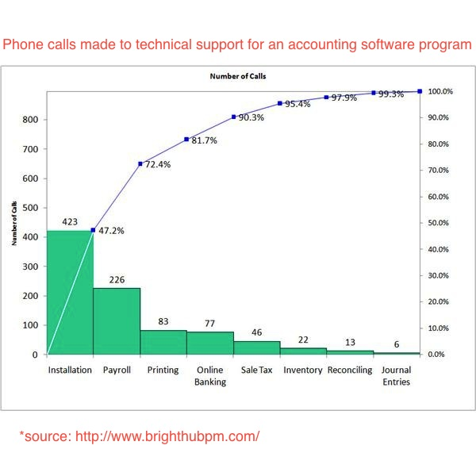

### This is your warning...

- But seriously, label axes and put a title on any graphics you create!

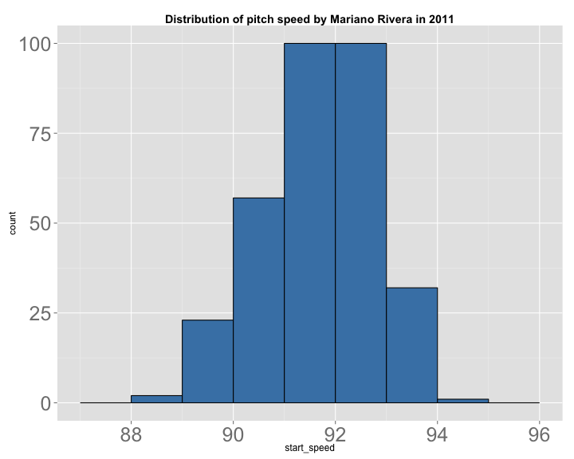

```
          [,1]
  [88,89)    2
  [89,90)   23
  [90,91)   57
  [91,92)  100
  [92,93)  100
  [93,94)   32
  [94,95)    1
```

- **Histograms** are essential to this class and statistics in general.
- A **histogram** displays the **distribution** of the numerical variable.
- In simpler terms, it tells us where values of a variable are likely to occur.
- This is essential information for modeling behavior in the **population**.
- The figures to the left portray **absolute frequencies**.

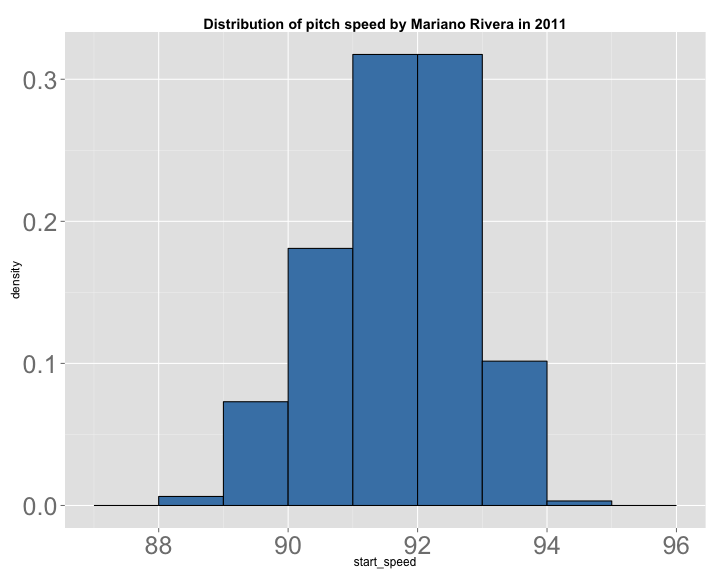

```
          [,1]
  [88,89) 0.006
  [89,90) 0.073
  [90,91) 0.181
  [91,92) 0.317
  [92,93) 0.317
  [93,94) 0.102
  [94,95) 0.003
```

- To find the **relative** (as opposed to absolute) frequencies, divide each count by the total number of observations.
- Notice how the shape of histogram is preserved. Only the y-axis is changes!
- Before we plotted the number of pitches in each bin. Now we have the percent of pitches within each bin.
- For example, only 0.6% of all these pitches are between 88 and 89 MPH!

### Percentiles

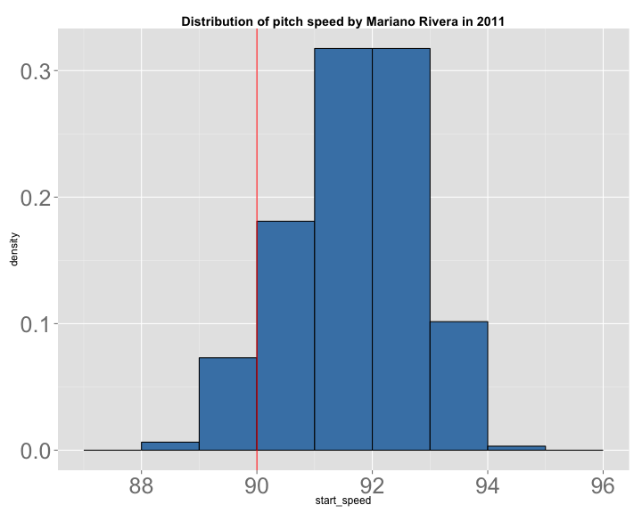

```
          [,1]
  [88,89) 0.006
  [89,90) 0.073
  [90,91) 0.181
  [91,92) 0.317
  [92,93) 0.317
  [93,94) 0.102
  [94,95) 0.003
```

### Percentiles continued

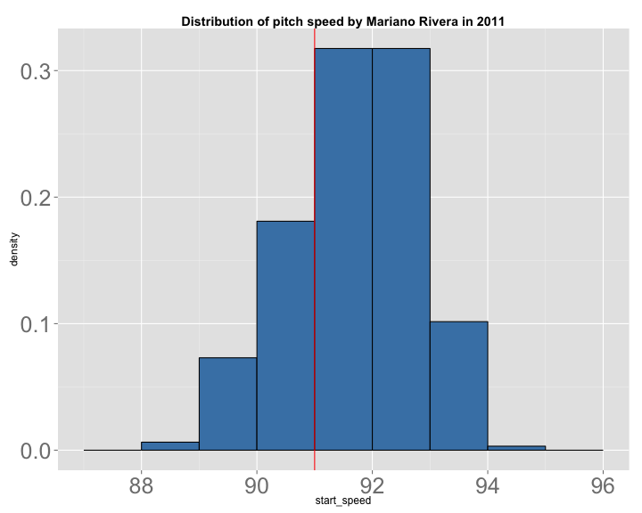

```
          [,1]
  [88,89) 0.006
  [89,90) 0.073
  [90,91) 0.181
  [91,92) 0.317
  [92,93) 0.317
  [93,94) 0.102
  [94,95) 0.003
```

### Foreshadowing

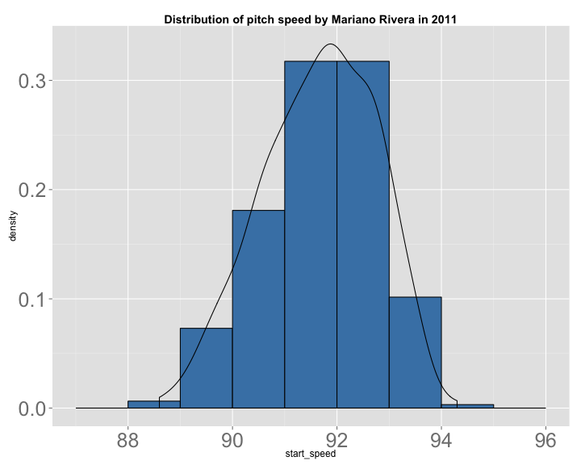

- In practice, we find a “smooth curve” based on **sample** data in order to make statements about quantities that we can't (or haven't) observed.
- For example, suppose I'm interested in the speed of Rivera's next pitch (a **random variable**).
- What is the probability that the next pitch less than 90 MPH?

[figure not shown]

### A Mental Exercise

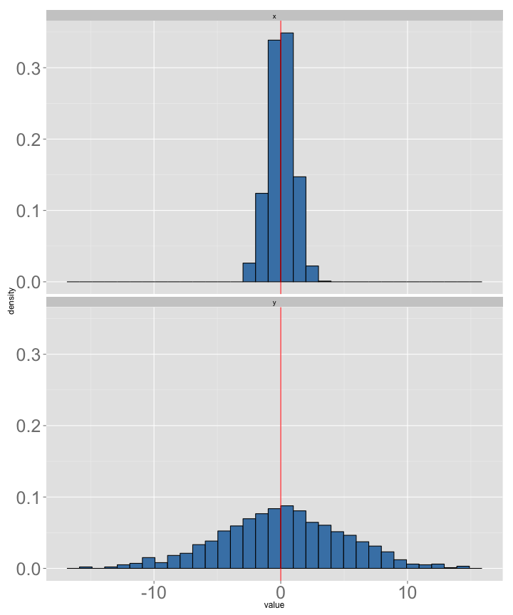

- What's the difference between these two histograms?
- There is more **variability** in the values of the bottom histogram!

### Measures of spread (or variability)

- **Range**: Maximum - Minimum
- **IQR**: Q3 - Q1
- **Variance and Standard Deviation**: see pages 75-79 in the lecture notes.